# Unhoused Funding Data Report

Tobin Haefele

## Introduction

In this report we partnered with the city of Missoula’s “Community Planning, Development, and Innovation” (CPDI) department, specifically with the Community Development Division. In an effort to understand and monitor Missoula’s unhoused population the CPDI department joined the Homeless Management Information System (HMIS) data collection effort by establishing a coordinated entry system. This allowed them to build datasets that can tell us much about the unhoused population. Along with this they have also executed a survey of the unhoused population to provide further data for us. Thanks to their hard work we have data to analyze and report on.

## Executive summary

This report presents an in-depth analysis of the CPDI department’s data, yielding several key insights:

Spending Distribution of funds was primaraly spent of prevention of homelessness rather than on those who are currently homeless. This is in line with the CPDI’s goal of preventing homelessness before it happens. The majority of funds are going towards rent which aligns with the goal of preventing homelessness before it happens.

Finally our demographic analysis found that the majority of funding is going towards the White demographic at 84%. This is in contrast to the general unhoused population within the MCES, where the percentage of White individuals is significantly lower at 67%. Further exploration of this disparity highlights potential inequities in funding allocation across minority demographic groups.

These findings offer valuable insights into the utilization and distribution of resources, underscoring the need for further exploration and potential adjustments to ensure more equitable access and targeted support for diverse demographic groups.

### Analyzing the utilization of the housing solutions fund by prevention or currently homeless

Our first analysis is how the housing solutions fund is being utilized to help the unhoused population. We will look at the total amounnt of money spent on prevention and the total amount spent on those who are currently homeless. Along with this we also want to look at what the funding is being used for and how much is being used in each category.

Initial analysis of the housing solutions fund found that a total of $193,628 was put towards either prevention or assistance to those currently unhoused. Of this total around 77% of the funding is being used for prevention of homelessness compared to 23% being allocated for those who are currently homeless. This disparity could be explained by the fact that it is much cheaper to prevent homelessness than it is to assist those who are currently homeless. This also aligns with the CPDI’s goal of preventing homelessness before it happens.

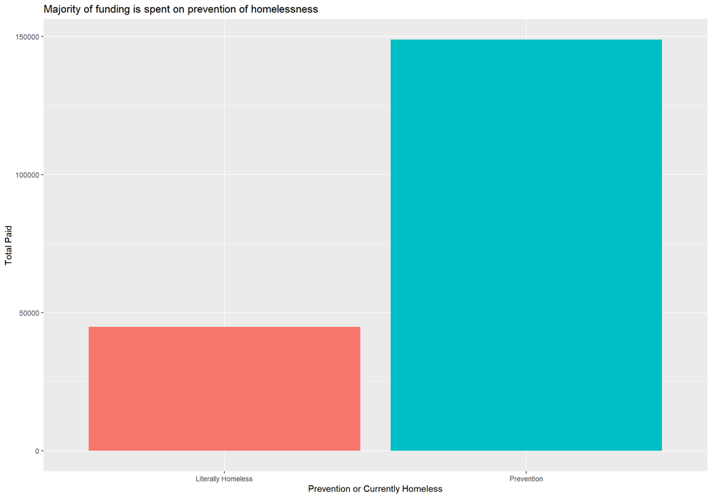

In this section I want to take a look at funding and how much is being spent on each category. This will allow us to view what the funding is being used for and how much is being spent on each category, allowing us to see if the funding is being used in the most optimal way.

Within the Prevention group we can see that the over 70% of funding is going towards rent while deposits make up around 14%. The makeup of these categories make sense as preventing eviction or helping with deposits to secure a place to live is a great way to prevent homelessness.

Among those currently homeless the majority of funding is going toward deposits (28%) and transportation (23%), both of these categories support the idea of helping those who are homeless either get into a home or get somewhere they have family/friends or a better opportunity.

Breakdown of Prevention Funding by Category

| Prevention or Literally Homeless | Category | Total Spent | Percent of Total |
| --- | --- | --- | --- |
| Prevention | Rent | $105,461 | 70.857% |
| Prevention | Deposits | $21,335 | 14.335% |
| Prevention | Other | $16,103 | 10.819% |
| Prevention | Utilities | $5,266 | 3.538% |
| Prevention | Applications | $372 | 0.250% |
| Prevention | Transportation | $300 | 0.202% |

Breakdown of Thoe Currently Homeless by Category

| Prevention or Literally Homeless | Category | Total Spent | Percent of Total |
| --- | --- | --- | --- |
| Literally Homeless | Deposits | $12,931.58 | 28.87% |
| Literally Homeless | Transportation | $10,322.75 | 23.05% |
| Literally Homeless | Other | $7,815.72 | 17.45% |
| Literally Homeless | Utilities | $6,185.57 | 13.81% |
| Literally Homeless | Rent | $5,938.60 | 13.26% |
| Literally Homeless | Applications | $1,597.39 | 3.57% |

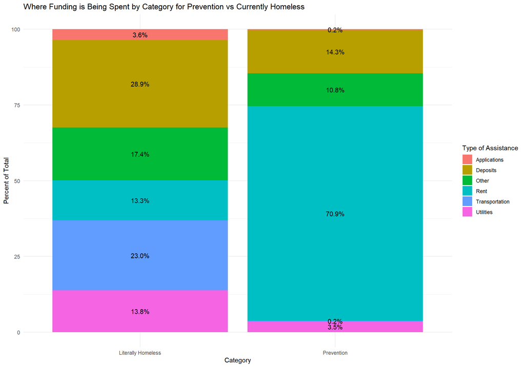

### Evaluating the sources of funding and their impact on services provided

In this next section we will take a look at where this funding is coming in from and how much is coming from each source. Using this data we can identify which sources are being utilized the most and which are being utilized the least.

Looking at the initial table we can see that just over half of the funding is coming from AHTF (Affordable Housing Trust Fund (City)) which is double the next closest source of funding OBT (Otto Bremer Trust) at 22%. Despite the EFSG (Emergency Solutions Grant (Human Resource Council program)) having a higher average spend on each individual at $762 per individual, this could be contributed to having a very small sample size of 10 individuals. The highest average spend on each individual when accounting for sample size ends up being the AHTF and WF (Wells Fargo) sources, at $559 and $529 respectively.

Overall Breakdown of Where Funding is Coming From

| Funding Source | Total Paid | Percent of Total | Number of Individuals Assisted |
| --- | --- | --- | --- |
| AHTF | $98,248.10 | 50.74% | 170 |
| EFSG | $7,624.33 | 3.94% | 10 |
| Home Coalition | $5,577.37 | 2.88% | 16 |
| Missoula Gives | $1,455.00 | 0.75% | 3 |
| OBT | $43,069.69 | 22.24% | 88 |
| Other sources/gifts | $5,307.53 | 2.74% | 17 |
| Providence | $8,965.55 | 4.63% | 24 |
| WF | $23,381.03 | 12.08% | 42 |

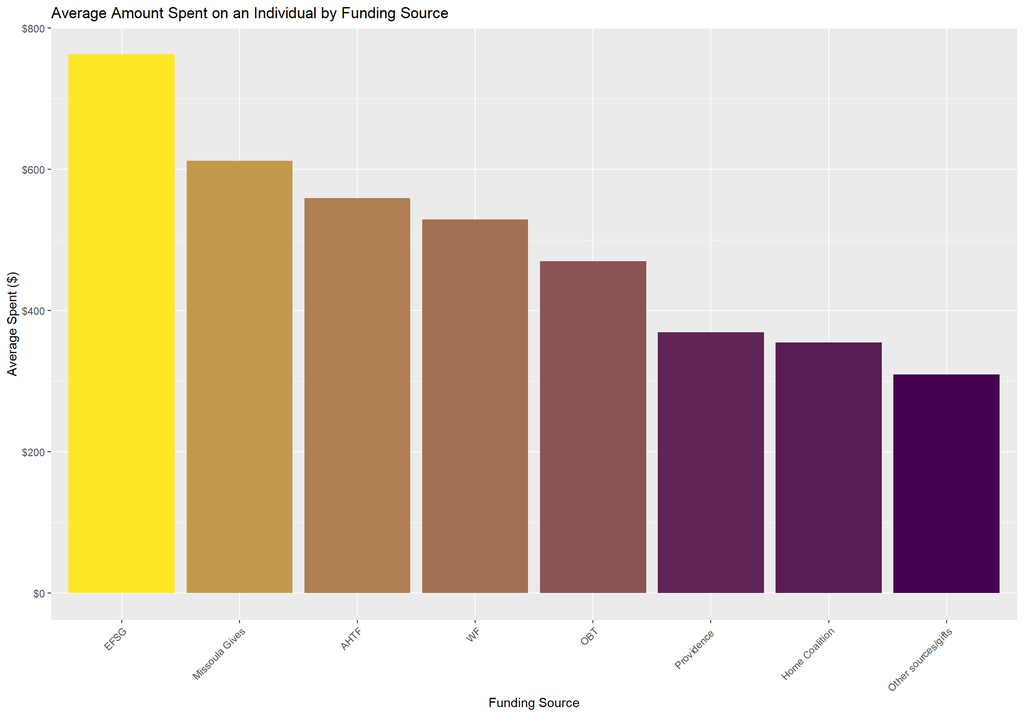

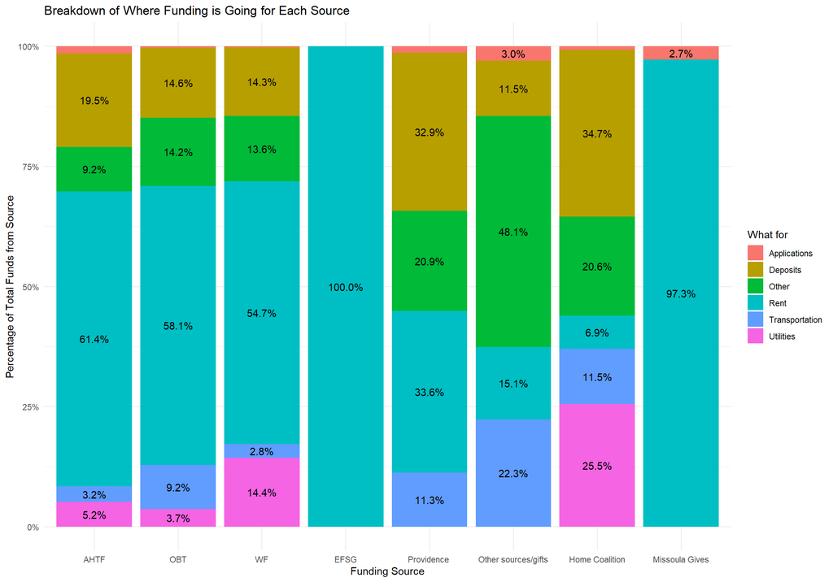

In this last section I want to focus on the agencies/programs that refer individuals to the Housing Solutions Fund. It’s apparent that HRM has the largest spread across each funding source, each of the major funding sources AHTF, OBT, and WF contributed to each of the top 5 referral forms. With more data I think it would be beneficiel to perform a basic analysis to see if there is a correlation between the amount of funding and the number of referrals from each agency/program. This could help us identify which agencies/programs are the most effective at referring individuals to the Housing Solutions Fund.

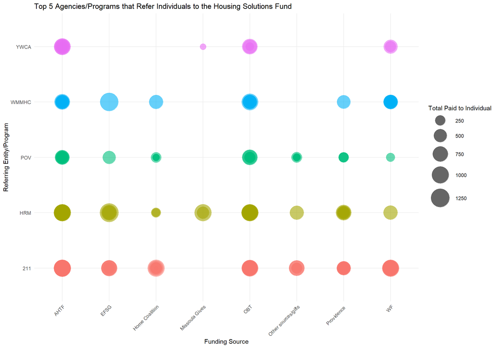

### Comparing demographics of those who are receiving funding to the overall population of those who are unhoused

An examination of the statistics reveals a notable trend in funding distribution, with an average of 84% allocated to individuals within the White demographic. This distribution is in contrast to the general unhoused population within the MCES, where the percentage of White individuals is significantly lower at 67%. Further exploration of this disparity highlights potential inequities in funding allocation across different demographic groups.

Breakdown of Housing Solutions Fund Distribution by Race/Ethnicity

| Race/Ethnicity | Number of Individuals | Total Paid | Average Paid per Individual | Percent of Total Paid |
| --- | --- | --- | --- | --- |
| White | 139 | $85,836.62 | $617.53 | 84.3% |
| American Indian, Alaska Native, or Indigenous | 17 | $10,743.93 | $632.00 | 10.5% |
| Black, African American, or African | 5 | $3,507.45 | $701.49 | 3.4% |
| Asian American/Pacific Islander | 2 | $1,772.00 | $886.00 | 1.7% |

Upon comparison, the demographic trends between individuals using the Housing Solutions Fund and the broader MCES population display similar distributions. However, a notable discrepancy emerges, particularly in the underrepresentation of Indigenous and Black individuals among users of the Housing Solutions Fund when contrasted with the demographic composition of the overall MCES population.

Breakdown of The Overall MCES Population by Race/Ethnicity

| Race/Ethnicity | Number of Individuals | Percent of Total Population |
| --- | --- | --- |
| White | 3257 | 67.6% |
| American Indian, Alaska Native, or Indigenous | 639 | 13.3% |
| Multiple | 551 | 11.4% |
| Black, African American, or African | 241 | 5.0% |
| Asian American/Pacific Islander | 93 | 1.9% |
| Hispanic/Latina/e/o | 40 | 0.8% |

### Conclusion

#### Spending Distribution:

Prevention Focus: The majority of funds are directed toward preventing homelessness, predominantly through rent support. This aligns with CPDI’s objective of preventing homelessness proactively.

#### Demographic Analysis:

Ethnic Disparities: While the funding primarily benefits the White demographic (84%), it’s notably higher than the 67% representation of Whites in the general unhoused population within MCES. This disparity could indicate potential inequities in fund allocation across minority groups. With more data we would be able to create a regression model to analyze if this difference is statistically significant.

These insights highlight both the alignment of fund distribution with prevention goals and the need for further exploration of equity in funding distribution among various demographic groups within the unhoused population.